# Programming with Python

## Basic of Python

#### Instructor: Bishal Rijal

# Collection types in Python

List

Tuple

Set

Dictionary

# List in Python

### A list is an ordered collection of elements accessible by index, lists are mutable

```python
l = [1,2,3,4,4,5] #
```

```python
l[0]
```

```
1
```

```python
l[-1] #negative indexing starts at -1 from the end and comes to the start of the list in decreasing order
```

```
5
```

```python
l[-2]
```

```
4
```

```python
len(l) #len is a function that returns the length of the list
```

```
6
```

```python
l[len(l)-1]
```

```
5
```

```python
l
```

```
[1, 2, 3, 4, 4, 5]
```

## Iterating through lists

```python
for i in range(len(l)):
    print(l[i])
```

```
1
2
3
4
4
5
```

```python
for number in l:
    print(number)
```

```
1
2
3
4
4
5
```

```python
l
```

```
[1, 2, 3, 4, 4, 5]
```

```python
for i in range(len(l)-1,-1,-1):
    print(l[i])
```

```
5
4
4
3
2
1
```

```python
l
```

```
[1, 2, 3, 4, 4, 5]
```

```python
l.pop() #removes the last element and returns it
```

```
5
```

```python
l
```

```
[1, 2, 3, 4, 4]
```

```python
l.remove(4) #removes the 1st occurence of the element given as the argument
```

```python
l
```

```
[1, 2, 3, 4]
```

```python
del l[1] #deletes the element at a specific index
```

```python
l
```

```
[1, 3, 4]
```

```python
l
```

```
[1, 3, 4]
```

```python
l.append(5) #adds an element to the end of the list
```

```python
l
```

```
[1, 3, 4, 5]
```

```python
l.extend([2,3]) #adds all elements of the list given as the argument to the end of the origional list
```

```python
l
```

```
[1, 3, 4, 5, 2, 3]
```

```python
l.append([2,3])
```

```python
l
```

```
[1, 3, 4, 5, 2, 3, [2, 3]]
```

## 2D lists

```python
mat = [[1,2,3],[4,5,6],[7,8,9]]
```

```python
mat
```

```
[[1, 2, 3], [4, 5, 6], [7, 8, 9]]
```

```python
mat[0]
```

```
[1, 2, 3]
```

```python
mat[0][0]
```

```
1
```

```python
for i in range(len(mat)):
    for j in range(len(mat[i])):
        print(i,j,mat[i][j])
```

```
0 0 1
0 1 2
0 2 3
1 0 4
1 1 5
1 2 6
2 0 7
2 1 8
2 2 9
```

```python
mat
```

```
[[1, 2, 3], [4, 5, 6], [7, 8, 9]]
```

## Calculating the sums of all the rows

```python
mat
```

```
[[1, 2, 3], [4, 5, 6], [7, 8, 9]]
```

```python
sums = []
```

```python
for i in range(len(mat)):
    sum_ = 0
    for j in range(len(mat[i])):
        sum_ += mat[i][j]
    sums.append(sum_)
sums
```

[output not shown]

# Collection data types - Tuples

- Ordered collection of elements accessible by index
- Share similar structure as lists but tuples are immutable

```python
t = (1,2,3,4,)
t
```

```
(1, 2, 3, 4)
```

```python
t[0]
```

```
1
```

```python
t[1]
```

```
2
```

```python
t[-1]
```

```
4
```

```python
t[-3]
```

```
2
```

```python
for i in range(len(t)):
    print(t[i])
```

```
1
2
3
4
```

```python
for num in t:
    print(num)
```

```
1
2
3
4
```

```python
t.append(4) #tuples are immutable
```

```
---------------------------------------------------------------------------
AttributeError                            Traceback (most recent call last)
<ipython-input-69-db1a4e4ef7c7> in <module>
----> 1 t.append(4) #tuples are immutable

AttributeError: 'tuple' object has no attribute 'append'
```

```python
t += (4,)
t
```

```
(1, 2, 3, 4, 4)
```

```python
t
```

```
(1, 2, 3, 4, 4)
```

```python
t *= 2
```

```python
t
```

```
(1, 2, 3, 4, 4, 1, 2, 3, 4, 4)
```

```python
tt = ((1,2,3),[4,5]) #nested tuple/2D tuple
tt
```

```
((1, 2, 3), [4, 5])
```

```python
for i in range(len(tt)):
    for j in range(len(tt[i])):
        print(tt[i][j])
```

```
1
2
3
4
5
```

# Collection data types - Sets

- Unordered collection of elements
- Sets are mutable
- Cannot contain duplicate entries

```python
a = {'cat','dog','mouse','parrot'}
b = {'mouse','elephant','cat','lion'}
```

```python
a
```

```
{'cat', 'dog', 'mouse', 'parrot'}
```

```python
b
```

```
{'cat', 'elephant', 'lion', 'mouse'}
```

```python
a.union(b)
```

```
{'cat', 'dog', 'elephant', 'lion', 'mouse', 'parrot'}
```

```python
a.intersection(b)
```

```
{'cat', 'mouse'}
```

```python
a.difference(b)
```

```
{'dog', 'parrot'}
```

```python
b.difference(a)
```

```
{'elephant', 'lion'}
```

```python
a.symmetric_difference(b)
```

```
{'dog', 'elephant', 'lion', 'parrot'}
```

```python
s = set("hello")
s
```

```
{'e', 'h', 'l', 'o'}
```

```python
s.add("i")
s
```

```
{'e', 'h', 'i', 'l', 'o'}
```

```python
s.add("o")
s
```

```
{'e', 'h', 'i', 'l', 'o'}
```

```python
s.remove("e")
s
```

```
{'h', 'i', 'l', 'o'}
```

### Find out all the unique items of the list

`L = [2,33,2,1,1,5,6,6,0]`

```python
L = [2,33,2,1,1,5,6,6,0]
l = []
for each in L:
    if each not in l:
        l.append(each)
l
```

```
[2, 33, 1, 5, 6, 0]
```

```python
list(set(L))
```

```
[0, 33, 2, 1, 5, 6]
```

# Collection data types - Dictionaries

```python
d = {"a":1,"b":2,"c":3}
d
```

```
{'a': 1, 'b': 2, 'c': 3}
```

```python
d["a"]
```

```
1
```

```python
d["c"]
```

```
3
```

```python
d["d"] = 4 #adds a new key value pair
d
```

```
{'a': 1, 'b': 2, 'c': 3, 'd': 4}
```

```python
d["a"] = 11 #updates the value for the existing key
d
```

```
{'a': 11, 'b': 2, 'c': 3, 'd': 4}
```

```python
del d['d']
d
```

```
{'a': 11, 'b': 2, 'c': 3}
```

```python
for key,value in d.items():
    print(key,value)
```

```
a 11
b 2
c 3
```

```python
for key in d.keys():
    print(key)
```

```
a
b
c
```

```python
for value in d.values():
    print(value)
```

```
11
2
3
```

```python
d1 = {"a":[1,2,3,4],"b":[5,6,7,8]}
d1
```

```
{'a': [1, 2, 3, 4], 'b': [5, 6, 7, 8]}
```

```python
d2 = {"a":{"x":12,"y":13},"b":(5,6,7,8)}
d2
```

```
{'a': {'x': 12, 'y': 13}, 'b': (5, 6, 7, 8)}
```

```python
d2["a"]
```

```
{'x': 12, 'y': 13}
```

```python
d2["a"]["x"]
```

```
12
```

```python
d2["b"]
```

```
(5, 6, 7, 8)
```

```python
d2["b"][-1]
```

```
8
```

# List Operations

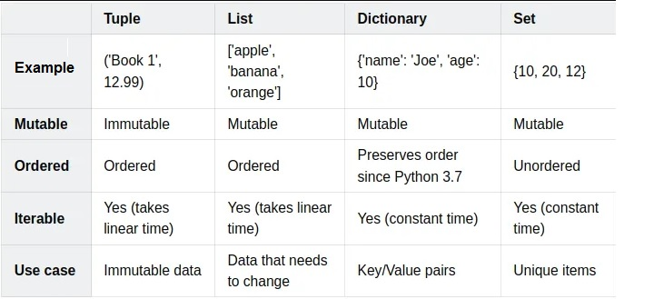

### Slicing:

It is used to get substrings or sublists from a list.

In Python List, there are multiple ways to print the whole list with all the elements, but to print a specific range of elements from the list, we use the Slice operation.

Slice operation is performed on Lists with the use of a colon(:).  
Syntax: list-name[start:end]

```python
a=[1,2,3,4,5,6]
a
```

```
[1, 2, 3, 4, 5, 6]
```

```python
a[:]
```

```
[1, 2, 3, 4, 5, 6]
```

```python
a[2:4]
```

```
[3, 4]
```

```python
a[2:]
```

```
[3, 4, 5, 6]
```

```python
a[:2]
```

```
[1, 2]
```

```python
a[-2:]
```

```
[5, 6]
```

```python
a[:-2]
```

```
[1, 2, 3, 4]
```

```python
a[-4:-2]
```

```
[3, 4]
```

# List Comprehension

Python's list comprehension feature is an easy approach to building lists.

By applying an expression to each item in an existing iterable (such as a list, tuple, or range) and optionally filtering the elements based on a condition, it enables you to construct a new list.

List construction with list comprehensions is more readable and effective than using conventional for loops.

Syntax: [expression for name in list]

```python
new=[x for x in a]
new
```

```
[1, 2, 3, 4, 5, 6]
```

```python
double=[2*x for x in a]
double
```

```
[2, 4, 6, 8, 10, 12]
```

```python
filter=[2*x for x in a if x>3]
filter
```

```
[8, 10, 12]
```

```python
list=[['a',1],['b',2],['c',3]]
list
```

```
[['a', 1], ['b', 2], ['c', 3]]
```

```python
li=[n*3 for (x,n) in list]
li
```

```
[3, 6, 9]
```

## Expressions can also contain user-defined functions.

```python
def add(x,y):
    return x+y
li=[[1,2],[3,4],[5,6]]
```

```python
[add(a,b) for (a,b) in li]
```

```
[3, 7, 11]
```

## Other Examples

```python
newlist = [x for x in range(10) if x < 5]
newlist
```

```
[0, 1, 2, 3, 4]
```

```python
pl=['C','C++','C#','Python','COBOL']
pl
```

```
['C', 'C++', 'C#', 'Python', 'COBOL']
```

```python
[x for x in pl if x!='C']
```

```
['C++', 'C#', 'Python', 'COBOL']
```

```python
[x.lower() for x in pl]
```

```
['c', 'c++', 'c#', 'python', 'cobol']
```

```python
word="Ram is a good boy and good student"
new=word.split()
new
```

```
['Ram', 'is', 'a', 'good', 'boy', 'and', 'good', 'student']
```

```python
num=len([1 for x in new if x=='good'])
num
```

```
2
```

# List Methods

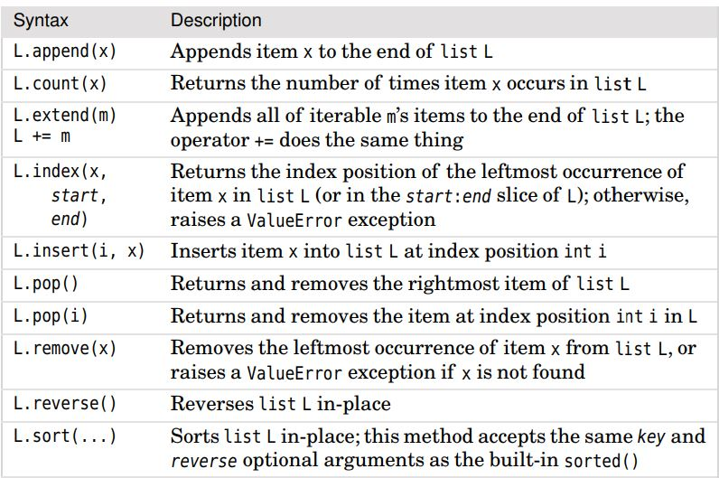

# Dictionary

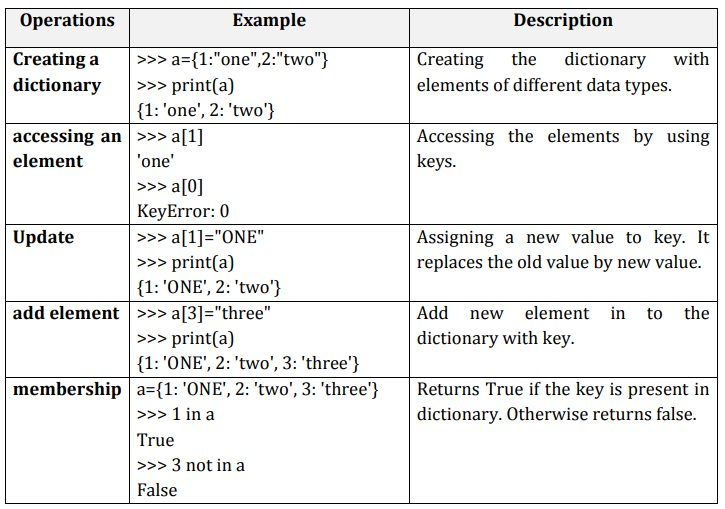

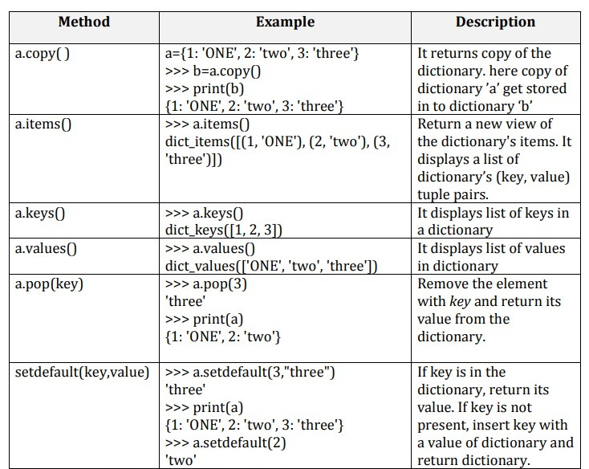

[figure not shown]

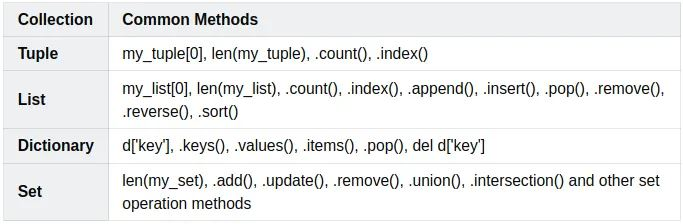

## Task

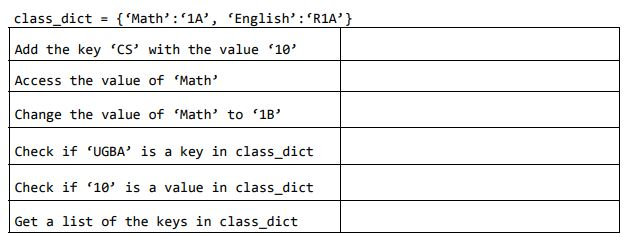

```python
d={'a':1,'b':2}
d
```

```
{'a': 1, 'b': 2}
```

```python
d['c']=1
d
```

```
{'a': 1, 'b': 2, 'c': 1}
```

```python
d['a']
```

```
1
```

```python
d['a']=5
d
```

```
{'a': 5, 'b': 2, 'c': 1}
```

```python
'a' in d
```

```
True
```

```python
'a' in d.keys()
```

```
True
```

```python
d.get('a')
```

```
5
```

```python
4 in d.values()
```

```
False
```

```python
def checkkey(dic, key):
    if key in dic.keys():
        print("Element is present")
        print("value =", dic[key])
    else:
        print("Not present")
checkkey(d,'a')
```

```
Element is present
value = 5
```

```python
def checkkey(dic, value):
    if value in dic.values():
        print("Value is present")
    else:
        print("Not present")
checkkey(d,5)
```

```
Value is present
```